## Naïve Bayes Classifier and Bayesian Linear Regression

# Introduction

## Requirements

This notebook contains implementation of Naïve Bayes Classifier and Bayesian Linear Regression. In order to be able to run the notebook it is necessary to have:

- MNIST training and test set
  - train-labels-idx1-ubyte
  - train-images-idx3-ubyte
  - t10k-labels-idx1-ubyte
  - t10k-images-idx3-ubyte
- CFAR training and test set: it is necessary to download the python version and to put the documents inside a floder called **cifar-10-batches-py**
- utils.py: put in the same folder of the notebook this python file

## Info

#### BLR

In the case of Bayesian Linear Regression, the grade of the polynomial was set to two for the following reasons:

- grade one was too low, and not considered enough precise
- grade greater than 2 was tryed, but the performance were not very good and the time used for the calculation was much higher

#### Loading vs Evaluating a model

It is possible using the boolean variables below to decide when to load a model or to create another one instead of using the one saved. Putting to True the boolean variables, the models will be loaded. This was thought to speed up the operations in case of re-run of the notebook.

```python
from utils import MNIST
import numpy as np
import math
import matplotlib.pyplot as plt
from scipy.stats import norm
import functools
import pickle
import time
from tabulate import tabulate
from sklearn.metrics import confusion_matrix
import itertools

classes = [0,1,2,3,4,5,6,7,8,9]
base='models_and_predictions/'

naive_bayes_load_predictions_mnist = True
naive_bayes_load_predictions_cfar = True
BLR_load_model_mnist_nobinary = True
BLR_load_model_cfar_nobinary = True
BLR_load_model_mnist = True
BLR_load_model_mnist_cleaned = True
BLR_load_model_cfar = True
BLR_mod_load_model_mnist = True
BLR_mod_load_model_mnist_cleaned = True
BLR_mod_load_model_cfar = True
```

# Load Datasets

#### CIFAR10

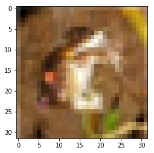

```
label of image is --> 6
```

```python
def unpickle(file):
    import pickle
    with open(file, 'rb') as fo:
        dict = pickle.load(fo, encoding='bytes')
    return dict

base_cfar10 = 'cifar-10-batches-py/'
cfar10_files = ['data_batch_1','data_batch_2','data_batch_3','data_batch_4','data_batch_5']

data_cfar10 = []
for f in cfar10_files:
    data_cfar10.append(unpickle(base_cfar10+f))
cfar10_test = unpickle(base_cfar10+'test_batch')

cfar10_meta = unpickle(base_cfar10+'batches.meta')

cfar10_training_images = np.array([d[b'data'] for d in data_cfar10]).flatten().reshape(50000,3072)
cfar10_training_labels = np.array([d[b'labels'] for d in data_cfar10]).flatten()
cfar10_test_images = cfar10_test[b'data']
cfar10_test_labels = np.array(cfar10_test[b'labels'])

# example
im = np.reshape(cfar10_training_images[0], (32,32,3), order='F')
plt.imshow(im)
plt.show()
print('label of image is --> '+str(cfar10_training_labels[0]))
```

#### MNIST

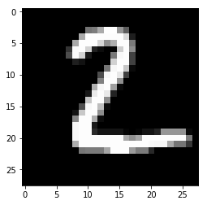

```
label of image is --> 2
```

```python
mndata = MNIST('.',return_type='numpy')
mnist_training_images, mnist_training_labels = mndata.load_training()
mnist_testing_images, mnist_testing_labels = mndata.load_testing()

# example of data
im = np.reshape(mnist_testing_images[1], (28,28))
plt.imshow(im, cmap='gray')
plt.show()
print('label of image is --> '+str(mnist_testing_labels[1]))
```

# Comment on dimensionality and distribution of classes

The classes' distribution can affect the classification, since if the prior for class A is a lot greater than prior of the other classes, the product *likelihood*prior* will be also greater (supposing the likelihood is not varying too much from one class to another) and will "attract" more data.  
Focusing on the dimensionality, the highest the dimensionality, the highest the number of combination of the features. If there are too many features but not enough data, it is not possible to have a sufficient number of data for each possible combination of features. This results in overfitting: we are creating a model using a set of data that describes only a part of the total dataset, that correspond to not being able to caracterize all the dataset corresponding to all the possible features. Below there is a plot showing the distribution of the elements per class: in the MNIST dataset it is possible to notice a greater variance in the distribution.

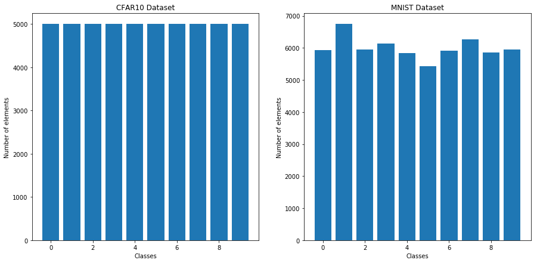

```python
plt.figure(figsize=(15,7))
plt.subplot(121)


plt.bar(range(0,10),[len(cfar10_training_labels[cfar10_training_labels==c]) for c in range(0,10)])
plt.title('CFAR10 Dataset')
plt.xlabel('Classes')
plt.ylabel('Number of elements')

plt.subplot(122)

plt.bar(range(0,10),[len(mnist_training_labels[mnist_training_labels==c]) for c in range(0,10)])
plt.title('MNIST Dataset')
plt.xlabel('Classes')
plt.ylabel('Number of elements')

plt.show()
```

# Data Cleaning

Before operating on the data, it could be useful to identify eventual outliers. Proceding in this way can possibly lead to a better solution later on. The procedure is the following:

- for each class calculate the mean
- calculate the average distance and the standard deviation of the distances for each class
- eliminate the images which distance from the mean is not in the interval *[average_distance - standard_dev,average_distance + standard_dev]*

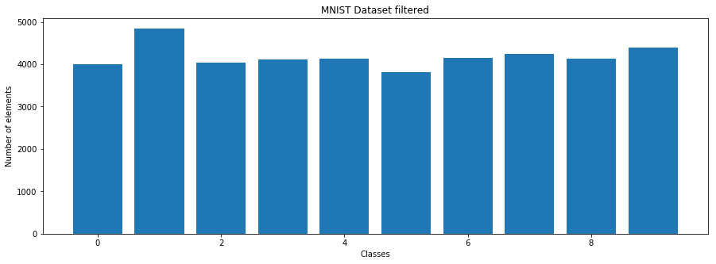

```
Number of elements after filtering ---> 41867
```

```python
avg_dist_for_class = []
std_for_class = []
imgs_mean = []

# for each class calculate the mean amd
# calculate the average distance and the standard deviation of the distances
for c in classes:
    cls_img = mnist_training_images[mnist_training_labels==c]
    img_mean = np.mean(cls_img,axis=0)
    distances = [np.linalg.norm(img_mean-e) for e in cls_img]
    std_for_class.append(np.std(distances))
    avg_dist_for_class.append(np.mean(distances))
    imgs_mean.append(img_mean)

# eliminate the images which distance from the mean is not
# in the interval [average_distance - standard_dev,average_distance + standard_dev]
mask = []
for e,lbl in zip(mnist_training_images,mnist_training_labels):
    dist = np.linalg.norm(imgs_mean[lbl]-e)
    if dist > avg_dist_for_class[lbl] + std_for_class[lbl] or \
            dist < avg_dist_for_class[lbl] - std_for_class[lbl]:
        mask.append(False)
    else:
        mask.append(True)
mask = np.array(mask)
filter_mnist_training_images=mnist_training_images[mask]
filter_mnist_training_labels=mnist_training_labels[mask]


plt.figure(figsize=(15,5))
plt.bar(range(0,10),[len(filter_mnist_training_images[filter_mnist_training_labels==c]) for c in range(0,10)])
plt.title('MNIST Dataset filtered')
plt.xlabel('Classes')
plt.ylabel('Number of elements')
plt.show()

print('Number of elements after filtering --->',len(filter_mnist_training_images))
```

From the graph above it is possible to notice that the classes are still not balanced. We are now balancing these classes, setting a number of images for each of them equal to 3500.

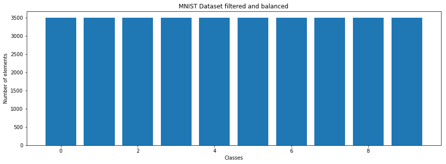

```python
batch_dim = 3500
num_classes = 10
img_dim = 784
new_mnist_training_images = np.array(functools.reduce(lambda x,y: np.append(x,y),
                              [filter_mnist_training_images[filter_mnist_training_labels==c][:batch_dim]
                               for c in range(0,10)])).reshape(batch_dim*num_classes,img_dim)
new_mnist_training_labels = []
for c in classes:
    new_mnist_training_labels+=[c]*batch_dim
len(new_mnist_training_labels)
new_mnist_training_labels = np.array(new_mnist_training_labels)

plt.figure(figsize=(15,5))
plt.bar(range(0,10),[len(new_mnist_training_images[new_mnist_training_labels==c]) for c in range(0,10)])
plt.title('MNIST Dataset filtered and balanced')
plt.xlabel('Classes')
plt.ylabel('Number of elements')
plt.show()
```

We obtained an equal distribution of the elements in each class. We can notice though that the number of training images is lower than the original amount. Is this gonna influence the trainig and the testing or not?

# Naïve Bayes

### Pros and Cons

It is possible to identify pros and cons of using this kind of classifier (Naive Bayes). A NB classifier is a simple classifier, and it is also very fast to converge if the assumption of independence holds. If it doesn't hold this method still allows to arrive to a good solution, but not the best one. On the other hand, if data are skewed, that means more training examples for one class than another, it can cause the decision boundaries to be biased. This cause the classifier to unwillingly prefer one class over the other. A similar trend can be seen when the indipendence costraint is not respected: the likelihood tend to be greater for classes that most violate the indipendence assumption.

### Our Classifier

Our classifier consist in a python class able to calculate the mean and variance of the training data, in order to evaluate the likelihood of the new data. In particular we used the probability density function in order to calculate the "probability", and not the actual probability (the integral of the function). This because with the actual probability, the highest the value with respect to the mean, the highest is going to be the probability. In our case we want the values closest to the mean to have more impact, that's why the use of the pdf.  
When the likelihood is computed, since we are implementing a naive method, we can consider the different probabilities of the different features as indipendent, and simply multiply them with one another. A common problem is to end up with a very small number at the end, since we are multiplying numbers that are less than 1.  
A solution could be to use the logarithm, and since the logarithm of a multiplication is the sum of the log of each element, that is what is computed instead of the multiplication. One fact to keep in mind is the following: the log of a probability is less than 0, since the probability is less than 1. When we calculate the likelihood we obtain something less than 0 that is going to be divided by something that is also less than zero (*sum over all the classes of likelihood*prior*). The numerator is going to be smaller and smaller as the likelihood is moving from a value of 1 to 0: so we obtain something less than 0 and very small. When this result is divided by something also less than 0 is going to be a big positive number.

#### What we obtain?

The smaller the likelihood, the smaller the log of it, but at the end is going to be very big. At the end we are not looking for the max value, we are rather looking for the smallest one thanks to this inversion of sign.

#### Log-Likelihood tuning

Sometimes it is possible that the log of the likelihood is -inf: this is due to a too small value of the likelihood. A part of data cleaning could be getting rid of -inf values, that during the sum of the logs will wrongly influenciate the result.

```python
class NaiveBayes:
    def __init__(self,classes,training_data,training_labels,test_data,test_labels):
        self.classes = classes
        self.training_data = training_data
        self.training_labels = training_labels
        self.test_data = test_data
        self.test_labels = test_labels
        self.mu = []
        self.sigma2 = []
        self.priors = np.array([])
        self.predictions = np.array([])

    def mean_and_var(self):
        for c in self.classes:
            imgs = self.training_data[self.training_labels == c]
            var = np.std(imgs,axis=0, ddof=1)
            mn = np.mean(imgs,axis=0)
            self.mu.append(mn)
            self.sigma2.append(var)
        self.mu = np.array(self.mu)
        self.sigma2 = np.array(self.sigma2)


    def gaussian(self, x, m, v):
        return 1 / np.sqrt(2 * np.pi * v) * np.exp(-(x - m)**2 / (2 * v))

    def likelihood(self, cls, data):
        """Used to calculate the likelihood"""

        log_prob = np.array([np.log(self.gaussian(d, m, v)) if v > 0.0 else 0 for
                         m, v, d in zip(self.mu[cls], self.sigma2[cls], data)])
        mn = min(log_prob[log_prob!=-math.inf])
        return sum(
                  [d if d != -math.inf else mn-1 for d in log_prob]
               )

    def prior(self):
        """Used to calculate the prior"""

        pr = []
        for c in self.classes:
            mask = self.training_labels == c
            pr.append(len(self.training_data[mask]))
        self.priors =  np.array([e/sum(pr) for e in pr])


    def predict(self):
        """Used to predict the labels of the test dataset"""

        labels = []
        for d_test_img, d_test_lbl in zip(self.test_data,self.test_labels):
            probs = []
            for c in self.classes:
                probs.append(self.likelihood(c,d_test_img)*self.priors[c])
            s = np.sum(probs)
            probs = [p/s for p in probs]
            labels.append(probs.index(min(probs)))
        self.predictions = np.array(labels)


    def accuracy(self):
        """Calculate the accuracy

            Returns:
              - number of correct predictions
              - number of incorrect predictions
              - accuracy in %
        """

        err = ok = 0
        for pred, eff in zip(self.predictions, self.test_labels):
            if pred == eff:
                ok = ok + 1
            else:
                err = err + 1
        acc = ok/(ok+err)
        return (ok,err,acc)

    def save_predictions(self, file_name):
        f = open(file_name,'wb')
        pickle.dump(self.predictions,f)
        f.close()

    def load_predictions(self, file_name):
        f = open(file_name,'rb')
        self.predictions = pickle.load(f)
        f.close()
```

We are just defining utility functions in order not to repeate the code many times. It allows to decide when to do the training or just load the predictions.

```python
def run_or_load_NB(model, load, file_name):
    """Function used to run the training part or just load the model"""

    if load == False:
        model.prior()
        model.mean_and_var()
        model.predict()
        model.save_predictions(file_name)
    else:
        model.load_predictions(file_name)

    print("accuracy -->",model.accuracy()[2],"with",model.accuracy()[0],
      "good classifications and",model.accuracy()[1],"wrong classifications")
```

```python
def plot_confusion_matrix(ax, true_label, prediction, classes,
                         title='Confusion matrix', cmap=plt.cm.Blues,
                         show=True):

    cm = confusion_matrix(true_label, prediction)
    np.set_printoptions(precision=2)

    ax.imshow(cm, interpolation='nearest', cmap=cmap)
    ax.set_title(title)
    tick_marks = np.arange(len(classes))
    ax.set_xticks(tick_marks, classes)
    ax.set_yticks(tick_marks, classes)

    thresh = cm.max() / 2.
    for i, j in itertools.product(range(cm.shape[0]), range(cm.shape[1])):
        ax.text(j, i, math.ceil(cm[i, j]*10000)/10000,
                 horizontalalignment="center",
                 color="white" if cm[i, j] > thresh else "black")


    ax.set_ylabel('True label')
    ax.set_xlabel('Predicted label')

    if show == True:
        plt.show()
```

#### Evaluation of Naive Bayes with MNIST training and test set

```python
nb_mnist1 = NaiveBayes(classes,mnist_training_images,mnist_training_labels,
                      mnist_testing_images,mnist_testing_labels)
run_or_load_NB(nb_mnist1,naive_bayes_load_predictions_mnist,base+'NB_mnist_predictions')
```

```
accuracy --> 0.8159 with 8159 good classifications and 1841 wrong classifications
```

#### Evaluation of Naive Bayes with CFAR training and test set

```python
nb_cfar10 = NaiveBayes(classes,cfar10_training_images,
                     cfar10_training_labels,cfar10_test_images,cfar10_test_labels)
run_or_load_NB(nb_cfar10,naive_bayes_load_predictions_cfar,base+'NB_cfar_predictions')
```

```
accuracy --> 0.2722 with 2722 good classifications and 7278 wrong classifications
```

#### Confusion Matrix

[figure not shown]

```python
f, (ax1, ax2) = plt.subplots(1, 2)
f.set_size_inches(20,20)
predictaions = pickle.load(open(base+'NB_mnist_predictions','rb'))
plot_confusion_matrix(ax1,mnist_testing_labels,predictions,classes, title='Confusion Matrix MNIST',show=False)

predictions = pickle.load(open(base+'NB_cfar_predictions','rb'))
plot_confusion_matrix(ax2,cfar10_test_labels,predictions,classes, title='Confusion Matrix CFAR')
```

#### Performance discussion

We can see how the Naive Bayes classifier used on to make predictions on the mnist dataset performs quite good, with an accuracy of 81.59 percent, while on the cfar dataset the performances are not that good, only 27.22 percent. The reason could be that in the cfar dataset are present images more complicated and with number of colors greater than mnist images. This increase in features could have lead to a more difficult understanding of the image and to a higher misclassification rate.

# Bayesian Linear Regression

The class below is used to create the bayesian linear regression method that will allow us to predict the type of an image using linear regression. Before being able to operate on the data, it is necessary to modify their structure, without changin the meaning and the content of each image. We defined the prior over w (*p(w)*) as a diagonal matrix with the element's value equal to 10000.

```python
class BLR():
    def __init__(self, classes, training_data, training_labels, test_data,test_labels, sigma, binary=True):
        """ Parameters:
             - classes: set with the classes for the classification
             - sigma: the sigma used for the prior over w
             - binary: if True one-hot vector encoding is used
        """

        # rapresent each class as a one-hot vector if binary = True
        self.classes = np.eye(len(classes)) if binary == True else classes
        self.training_data = training_data
        # rapresent each label as a one-hot vector
        self.training_labels = [self.classes[c] for c in training_labels]\
                        if binary == True else training_labels
        self.test_data = test_data
        self.test_labels = test_labels
        self.sigma = sigma
        self.binary = binary

    def adjust_data(self, k):
        """modify the input data to have them in the right format"""

        self.k = k
        def redifine_data(x):
            return np.array([
                    np.array([x_i**n for n in range(k + 1)]).flatten() for x_i in np.array(x)
                ])
        X = redifine_data(self.training_data)
        self.training_data = np.hstack( (np.array([np.ones(len(X))]).T, X ))
        X = redifine_data(self.test_data)
        self.test_data = np.hstack( (np.array([np.ones(len(X))]).T, X ))

    def generate_w(self):
        """Used to generate w given training data"""

        X = self.training_data
        t0 = time.time()
        X2 = X.T.dot(X)/self.sigma
        S = np.eye(len(X2))*10000
        X2inv = np.linalg.inv(X2+np.linalg.inv(S))
        self.w = X2inv.dot(X.T).dot(self.training_labels)/self.sigma

    def make_prediction(self):
        """Makes prediction given test data and w"""

        self.predictions = self.test_data.dot(self.w)
        if self.binary == True:
            self.predictions = [np.argmax(e) for e in self.predictions]

    def change_test_set(self, test_data, test_labels):
        """Allow to change the test set, in order to test the model with different dataset"""

        self.test_data = np.array([
                    np.array([x_i**n for n in range(self.k + 1)]).flatten() for x_i in np.array(test_data)
                ])

        self.test_labels = test_labels

    def accuracy(self):
        """Calculate the accuracy

            Returns:
              - number of correct predictions
              - number of incorrect predictions
              - accuracy in %
        """
        err = ok = 0
        for pred, eff in zip(self.predictions, self.test_labels):
            if round(pred) == eff:
                ok = ok + 1
            else:
                err = err + 1
        acc = ok/(ok+err)
        return (ok,err,acc)

    def save_model(self, file_name):
        """Save the model, that means saving w and the parameters sigma, binary, K, classes"""

        f = open(file_name+'_w','wb')
        pickle.dump(self.w,f)
        f.close()
        f = open(file_name+'_param','wb')
        pickle.dump([self.sigma,self.binary,self.k,self.classes],f)
        f.close()

    def load_model(self, file_name):
        """Load the model, that means loading w and the parameters sigma, binary, K, classes"""

        f = open(file_name+'_w','rb')
        self.w = pickle.load(f)
        f.close()
        f = open(file_name+'_param','rb')
        [self.sigma,self.binary,self.k,self.classes] = pickle.load(f)
        f.close()
```

We are just defining an utility function in order not to repeate the code many times. It allows to decide when to do the training or just load the model.

```python
def run_or_load(model, load, k, file_name):
    """Function used to run the training part or just load the model"""

    model.adjust_data(k)
    if load == False:
        model.generate_w()
        model.save_model(file_name)
    else:
        model.load_model(file_name)
    model.make_prediction()

    print("accuracy -->",model.accuracy()[2],"with",model.accuracy()[0],
      "good classifications and",model.accuracy()[1],"wrong classifications")
```

#### BLR with MNIST and CFAR dataset

We are now going to try to predict the classes of the MNIST and CFAR using the bayesian linear regression, and plotting the result.

```python
c = BLR(classes,mnist_training_images,mnist_training_labels,mnist_testing_images,
        mnist_testing_labels,0.05,binary=False)
run_or_load(c,BLR_load_model_mnist_nobinary,2,base+'BLR_mnist_k2_True_s05_nobinary')

c_cfar = BLR(classes,cfar10_training_images,cfar10_training_labels,
             cfar10_test_images,cfar10_test_labels,0.05,binary=False)
run_or_load(c_cfar,BLR_load_model_cfar_nobinary,2,base+'BLR_cfar_k2_True_s05_nobinary')
```

```
accuracy --> 0.2456 with 2456 good classifications and 7544 wrong classifications
accuracy --> 0.1136 with 1136 good classifications and 8864 wrong classifications
```

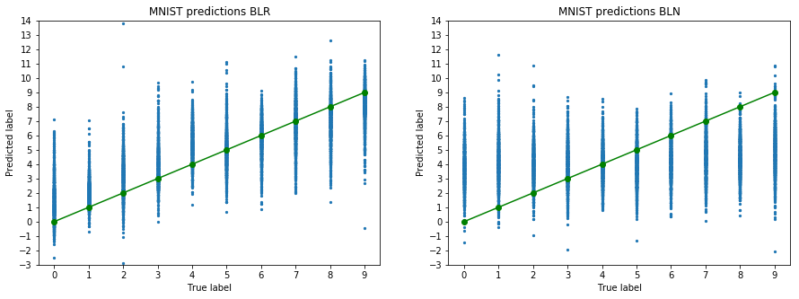

```python
plt.figure(figsize=(15,5))
plt.subplot(121)

plt.scatter(mnist_testing_labels, c.predictions, s=5)
plt.plot(np.arange(0,10), np.arange(0,10), 'k-o', c='g')
plt.xticks(np.arange(0,10))
plt.yticks(np.arange(-3,15))
plt.ylim(-3,14)
plt.xlabel('True label')
plt.ylabel('Predicted label')
plt.title('MNIST predictions BLR')

plt.subplot(122)

plt.scatter(cfar10_test_labels, c_cfar.predictions, s=5)
plt.plot(np.arange(0,10), np.arange(0,10), 'k-o', c='g')
plt.xticks(np.arange(0,10))
plt.yticks(np.arange(-3,15))
plt.ylim(-3,14)
plt.xlabel('True label')
plt.ylabel('Predicted label')
plt.title('MNIST predictions BLN')
plt.show()
```

```python
def MSE(predicted_labels, target_labels):
    error = 0
    for p, t in zip(predicted_labels, target_labels):
        error += np.square(p-t)
    return error/len(predicted_labels)
print('MSE MNIST -->',MSE(c.predictions,mnist_training_labels))
print('MSE CFAR -->',MSE(c_cfar.predictions,cfar10_training_labels))
```

```
MSE MNIST --> 15.4242969459
MSE CFAR --> 10.2618946785
```

As we can see above, the prediction accuracy is really low:

- 24.56 for MNIST dataset
- 11.36 for CFAR dataset

From the scatter plot is also possible to notice that the true label and the predicted label differ a lot, and sometimes we are also predicting classes that where not present in the initial dataset.

### Problems encountered and solution proposed

We are working with discrete variables, but linear regression works with continues variables. In order to solve this problem we decided to treat each label as a one-hot vector. In this way we will not obtain a vector of weights of dimension *K+1* (where K is the grade of the polynomial and the + 1 is the grade zero term), but a matrix of dimension *K+1 x number_different_classes*. At the end of the prediction phase, for each test image not a single class will be returned but a set of N predictinos, where N is the number of different classes. Picking the highest value will give us the (hopefully) correct prediction.  
We are going to evaluate this method using:

- MNIST dataset
- MNIST dataset without outliers
- CFAR dataset

#### BLR with MNIST dataset (with and without outliers)

```
accuracy --> 0.8895 with 8895 good classifications and 1105 wrong classifications
accuracy --> 0.8774 with 8774 good classifications and 1226 wrong classifications
```

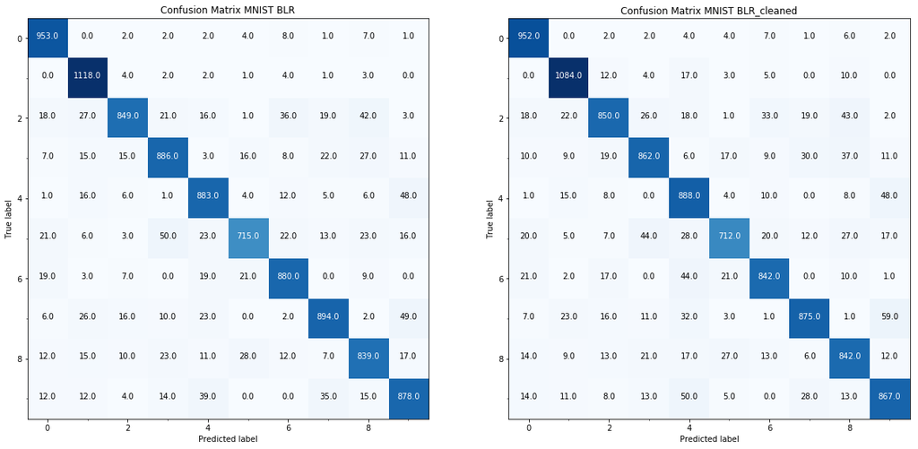

```python
f, (ax1, ax2) = plt.subplots(1, 2)
f.set_size_inches(20,20)

c = BLR(classes,mnist_training_images,mnist_training_labels,\
        mnist_testing_images,mnist_testing_labels,0.05)

c_clean = BLR(classes,new_mnist_training_images,new_mnist_training_labels,\
              mnist_testing_images,mnist_testing_labels,0.05)

run_or_load(c,BLR_load_model_mnist,2,base+'BLR_mnist_k2_True_s05')
run_or_load(c_clean,BLR_load_model_mnist_cleaned,2,base+'BLR_clean_k2_True_s05')


plot_confusion_matrix(ax1,mnist_testing_labels,c.predictions,classes,
                      title='Confusion Matrix MNIST BLR',show=False)
plot_confusion_matrix(ax2,mnist_testing_labels,c_clean.predictions,
                      classes,title='Confusion Matrix MNIST BLR_cleaned')
```

#### BLR with CFAR dataset

```
accuracy --> 0.3211 with 3211 good classifications and 6789 wrong classifications
```

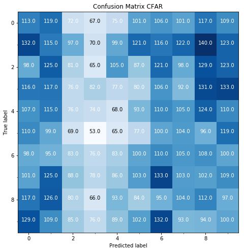

```python
f, ax = plt.subplots(1, 1)
f.set_size_inches(8,8)
c_cfar = BLR(classes,cfar10_training_images,cfar10_training_labels,cfar10_test_images,cfar10_test_labels,0.05)
run_or_load(c_cfar,BLR_load_model_cfar,2,base+'BLR_cfar_k2_True_s05')

plot_confusion_matrix(ax,mnist_testing_labels,c_cfar.predictions,classes,title='Confusion Matrix CFAR')
```

#### Limitation on the previous approach

While using the one-hot vector to define a class for a given image, we are saying that the "contribute" of that image for a given class C is maximum, but completely inexistent for all the other classes. It could be better to procede in the following way:

- given a class, take the images that are far away from the mean
- for that images look if they can contribute in defining also other classes (not a one-hot vector anymore)

In order to exploit this idea we created a class, that behaves exactly as BLS, but with the addition of the methods to build up the labels to use in the training.

# Bayesian Linear Regression - new approach

We are starting to calculate the average image for each class and then the distances of the images belonging to each class with the average calculated before.  
Having now the set of distances for each class, we evaluate mean and variance. Supposing that the distribution of the distances follows a normal distribution, mean and variance are used to evaluate the pdf for each class. Given a distance, if the evaluation of the pdf in that point is small enough with respect to the maximum of the pdf it means that the image is far away from the class mean, so it is possible to look how similar it is to the other classes.  
Operating in this way lead us to the following situation:

- given a class, some images have as label a one-hot vector
- given the same class, other images will have as label a vector with: a 1 with respect to their class and other numbers with respect to other classes.

In order to identify the images far enough from the class mean, we are looking at the ratio between the pdf evaluated for a given distance and the max of the pdf: if 1 - ratio is greater than 0.8, then the image is considered far from the mean.

#### How to fill the label vector

We said before that when an image is far from its class mean, the label will be a vector with a 1 with respect to their class and other numbers with respect to other classes. Given an image I of class C1, the vector-label will have 1 with respect to C1 and *pdf(distance_between_I_and_mean_of_C)* for each class C different from C1.

```python
class BLR_mod(BLR):
    def __init__(self, classes, training_data,
                 training_labels, test_data,test_labels, sigma, binary=True):
        self.original_classes = classes
        self.classes = np.eye(len(classes)) if binary == True else classes
        self.training_data = training_data
        self.training_labels = training_labels
        self.test_data = test_data
        self.test_labels = test_labels
        self.mu = []
        self.sigma2 = []
        self.top_gaussian = []
        self.class_mean = []
        self.sigma = sigma
        self.binary = binary

    def gaussian(self, x, m, v):
        return 1 / np.sqrt(2 * np.pi * v) * np.exp(-(x - m)**2 / (2 * v))

    def mean_and_var(self):
        """Function that calculates mean and variance of the distances for each class"""

        for c in self.original_classes:
            class_mean = np.mean(self.training_data[self.training_labels == c],axis=0)
            distances = [np.linalg.norm(class_mean-e) for e in self.training_data[self.training_labels == c]]
            # var of the distances
            var = np.std(distances,axis=0, ddof=1)
            # mean of the distances
            mn = np.mean(distances,axis=0)
            self.class_mean.append(class_mean)
            self.top_gaussian.append(self.gaussian(mn,mn,var))
            self.mu.append(mn)
            self.sigma2.append(var)
        self.mu = np.array(self.mu)
        self.sigma2 = np.array(self.sigma2)


    def labels(self):
        """Used to redifine the label vectors, in order to create them not as one-hot vector"""

        labels = np.zeros((len(self.training_labels),10))
        i = 0
        for c,e in zip(self.training_labels,self.training_data):
            dist = np.linalg.norm(self.class_mean[c]-e)
            ratio = 1 - self.gaussian(dist,self.mu[c],self.sigma2[c])/self.top_gaussian[c]
            labels[i] = self.classes[c]
            if ratio > 0.8:
                for cls in self.original_classes:
                    if cls != c:
                        dist = np.linalg.norm(self.class_mean[cls]-e)
                        labels[i][cls] = self.gaussian(dist,self.mu[cls],self.sigma2[cls])
            i += 1
        self.training_labels = labels
```

We are just defining an utility function in order not to repeate the code many times. It allows to decide when to do the training or just load the model.

```python
def run_or_load_mod(model, load, k, file_name):
    if load == False:
        model.mean_and_var()
        model.labels()
        model.adjust_data(k)
        model.generate_w()
        model.save_model(file_name)
    else:
        model.adjust_data(k)
        model.load_model(file_name)
    model.make_prediction()
    print("accuracy -->",model.accuracy()[2],"with",model.accuracy()[0],
      "good classifications and",model.accuracy()[1],"wrong classifications")
```

#### BLR mod with MNIST dataset

```
accuracy --> 0.89 with 8900 good classifications and 1100 wrong classifications
accuracy --> 0.8779 with 8779 good classifications and 1221 wrong classifications
```

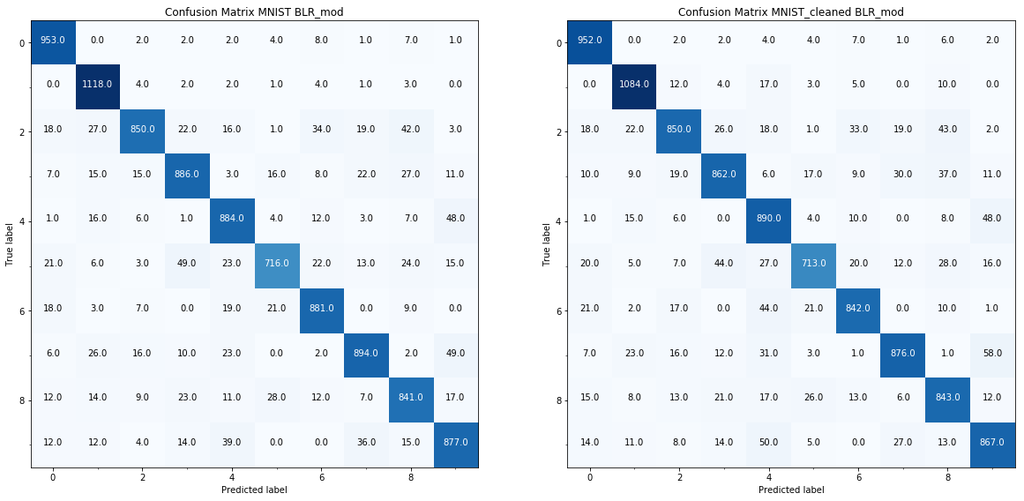

```python
f, (ax1, ax2) = plt.subplots(1, 2)
f.set_size_inches(20,20)
c_BLR_mod1 = BLR_mod(classes,mnist_training_images,mnist_training_labels,
                     mnist_testing_images,mnist_testing_labels,0.05)
BLR_mod_cleaned = BLR_mod(classes,new_mnist_training_images,new_mnist_training_labels,
                               mnist_testing_images,mnist_testing_labels,0.05)

run_or_load_mod(c_BLR_mod1,BLR_mod_load_model_mnist,2,base+'BLR_mod_mnist_k2_s05')
run_or_load_mod(BLR_mod_cleaned,BLR_mod_load_model_mnist_cleaned,2,base+'BLR_mod_mnist_cleaned_k2_s05')

plot_confusion_matrix(ax1,mnist_testing_labels,c_BLR_mod1.predictions,classes,
                      title='Confusion Matrix MNIST BLR_mod',show=False)
plot_confusion_matrix(ax2,mnist_testing_labels,BLR_mod_cleaned.predictions,classes,
                      title='Confusion Matrix MNIST_cleaned BLR_mod')
```

#### BLR mod with CFAR

```
accuracy --> 0.3215 with 3215 good classifications and 6785 wrong classifications
```

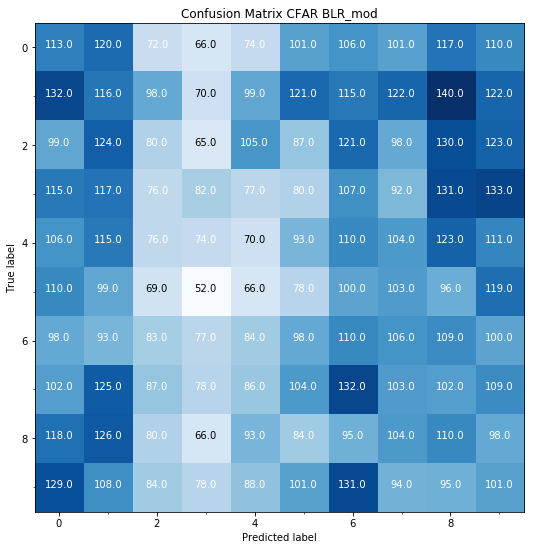

```python
f, ax = plt.subplots(1, 1)
f.set_size_inches(9,9)
c_BLR_mod1 = BLR_mod(classes,cfar10_training_images,cfar10_training_labels,
                     cfar10_test_images,cfar10_test_labels,0.05)

run_or_load_mod(c_BLR_mod1,BLR_mod_load_model_cfar,2,base+'BLR_mod_cfar_k2_s05')

plot_confusion_matrix(ax,mnist_testing_labels,c_BLR_mod1.predictions,classes,
                      title='Confusion Matrix CFAR BLR_mod')
```

#### Conclusions

It should be necessary to investigate more this solution, trying to figure out a measure that can better express the relation between an image and a class.

# Naive bayesian vs Bayesian Linear Regression

The Naive Bayesian classifier was performing quite good, especially with respect to bayesian linear regression. The fact that the bayesian linear regression was performing really bad was due to the usage of discrete classes as continuous ones: this problem was solved introducing the one-hot vector rapresentation.  
With the one-hot vector rapresentation was like building a different model for each class, taking into account only the images belonging to a specific class and not all of them. This solution was way better than the one obtained with the naive bayesian classification.  
The dicision to take into account also the distance between an image of class C and all the other classes different from C allowed to improve even more the solution.  
It is necessary to notice that we inserted some semplification in the data rapresentation for the bayesian linear regression part. We rapresented the first column of the matrix containing all the images as a column of ones. In reality it should not have been a single column, but a set of 784 column all set to 1. Using this approach the result obtained will be a bit better than the one obtained now. The side effect though would have been a huge amount of time in order to finish the computation of X.T.dot(X). We decided not to use it and stick with the more simple data format.